# SG1022 Seminar 2: Composite Indicators

## Correlation matrix

You can create a correlation matrix to view multiple bi-variate correlations at once:

```r
# Remember we created a vector of indicator names earlier
environ_cor <- cor(wdi[, indicators_environ], use = 'complete.obs')

environ_cor
```

```
##                    electricity_use co2_emissions population_growth
## electricity_use       1.0000000000    0.63019334     -0.0006567439
## co2_emissions         0.6301933356    1.00000000      0.1834125643
## population_growth    -0.0006567439    0.18341256      1.0000000000
## alternative_energy    0.4010761472   -0.07324789     -0.2398352393
##                    alternative_energy
## electricity_use            0.40107615
## co2_emissions             -0.07324789
## population_growth         -0.23983524
## alternative_energy         1.00000000
```

## Easier view

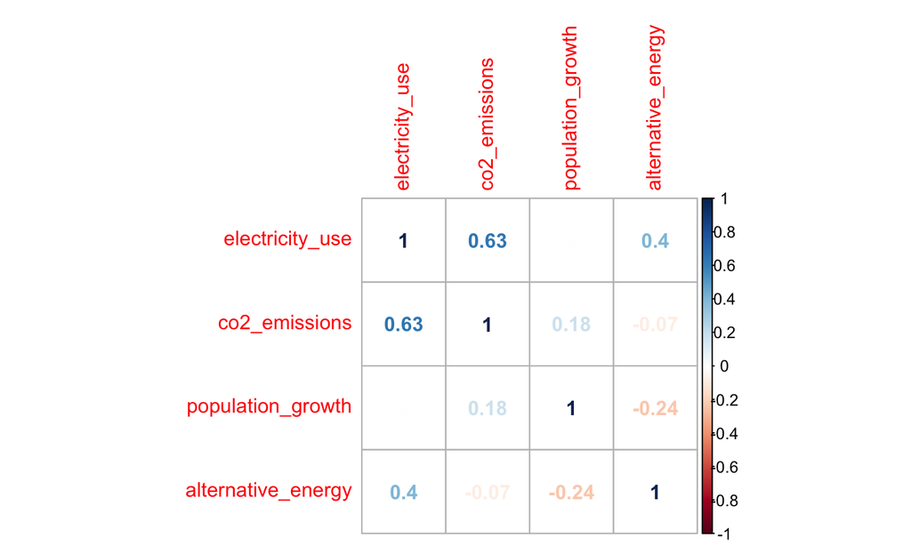

```r
corrplot::corrplot(environ_cor, method = 'number')
```

## Rescaling

As we discussed in the lecture, there are multiple ways you can rescale your component variables so that they are all on the same scale, e.g. **Min-Max**, and **Z-Scores**.

Before we learn these specific tools, let's learn a powerful new capability: creating your own functions.

## Creating Functions

Use the `function` function to create new functions!

E.g. we can create a function to find the sample mean (\(\bar{x} = \frac{\sum x}{n}\)) of a vector.

```r
fun_mean <- function(x){
    sum(x) / length(x)
}

## Find the mean
fun_mean(x = wdi$electricity_use)
```

```
## [1] 3749.494
```

## Why create functions?

Functions:

- Simplify your code if you do repeated tasks.
- Lead to fewer mistakes.
- Are easier to understand.
- Save time over the long run–a general solution to problems in different contexts.

## Min-Max function

To create a function to do Min-Max rescaling remember the equation:

\[ I_{u,t} = \frac{x_{u,t} - \mathrm{min}(\mathrm{X})}{\mathrm{max}(\mathrm{X}) - \mathrm{min}(\mathrm{X})} \]

So the R function would be:

```r
min_max <- function(x) {
            (x - min(x, na.rm = T))/
            (max(x, na.rm = T) - min(x, na.rm = T))
}
```

## Min-Max rescale

Now use the function:

```r
wdi$altern_min_max <- min_max(wdi$alternative_energy)
```

## Examine Min-Max distribution

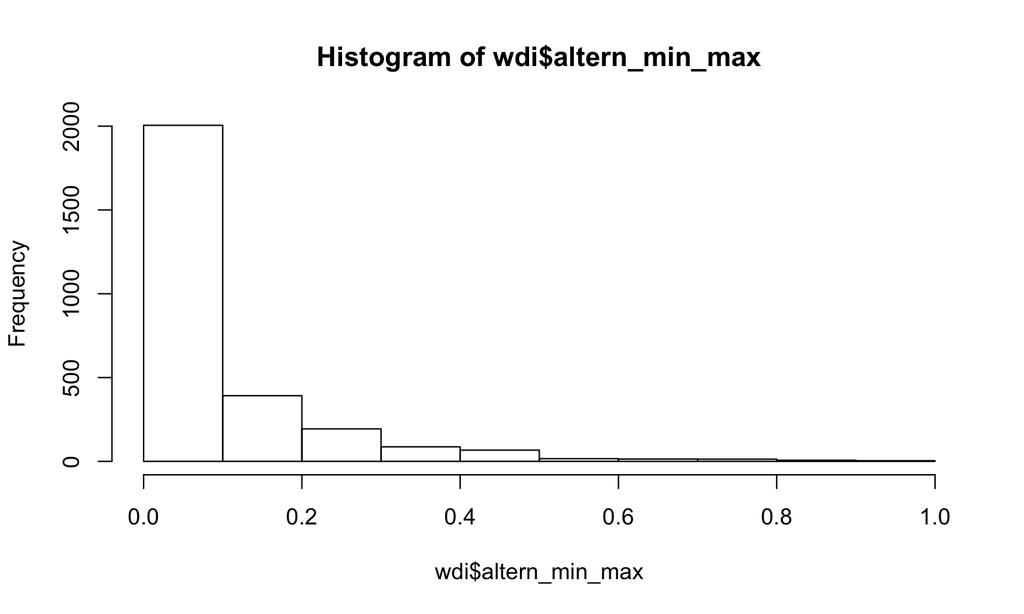

```r
hist(wdi$altern_min_max)
```

## Z-Score rescale

The equation for Z-Scores is:

\[ I_{u,t} = \frac{x_{u,t} - \mu_{\mathrm{X}}}{\sigma_{\mathrm{X}}} \]

So, the R function would be:

```r
z_score <- function(x) {
                (x - mean(x, na.rm = T)) /
                sd(x, na.rm = T)
}
```

## Z-Score rescale

Now use the function:

```r
wdi$altern_z_score <- z_score(wdi$alternative_energy)
```

## Examine Z-Score distribution

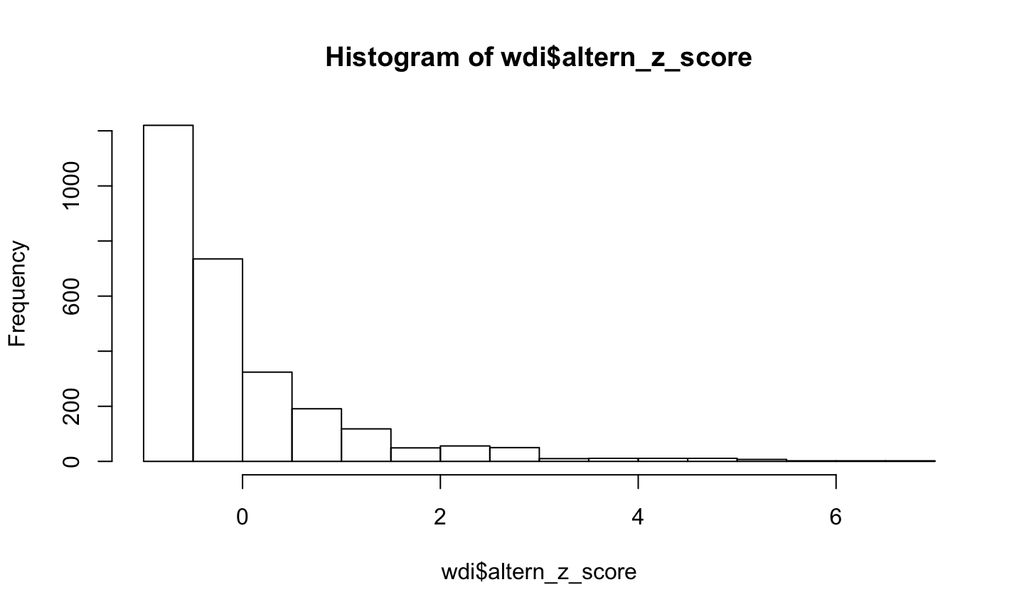

```r
hist(wdi$altern_z_score)
```

## Reverse a variable's direction

The equation to reverse a variable's direction:

\[ I_{u,t} = \mathrm{max}(\mathrm{X}) - x_{u,t} \]

So the function would be:

```r
reverse_direction <- function(x) max(x, na.rm = T) - x
```

Now use the function:

```r
wdi$altern_z_reverse <- reverse_direction(wdi$altern_z_score)
```

## Examine reversed distribution

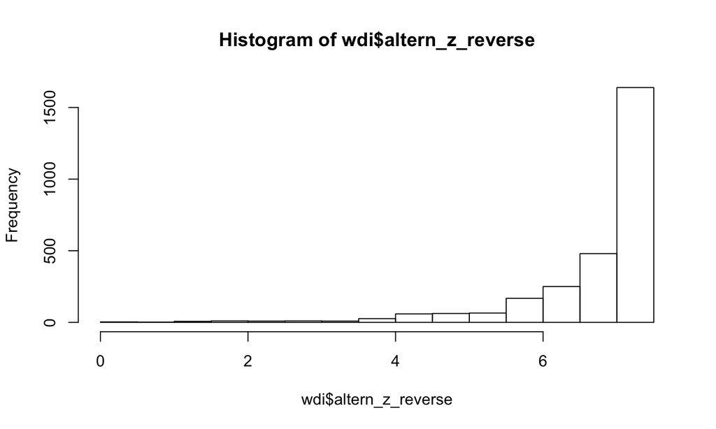

```r
hist(wdi$altern_z_reverse)
```

## You try

Put the following other variables on a Z-Score scale:

## Weight/Aggregate

Once we have our rescaled components, we then decide how to weight and aggregate our indicators.

For this course you will use '**expert-judgement**'.

## Weight/Aggregate example

Imagine we have four variables that we want to combine into an Environmental Unsustainability index: `electricity_use`, `co2_emissions`, `population_growth`, and `alternative_energy`.

We have use z-scores to rescale them and reversed the direction of `alternative_energy`.

The results are in a data frame called `wdi_sub`.

## Weight/Aggregate example

We think that `co2_emissions` is particularly important so we give it a weighting of 0.3, the others have a weighting of 0.1:

```r
wdi_sub$unsustainability <- wdi_sub$co2_emissions * 0.3 +
                                  wdi_sub$electricity_use * 0.1 +
                                  wdi_sub$population_growth * 0.1 +
                                  wdi_sub$alternative_energy * 0.1
```

## Component indicator results

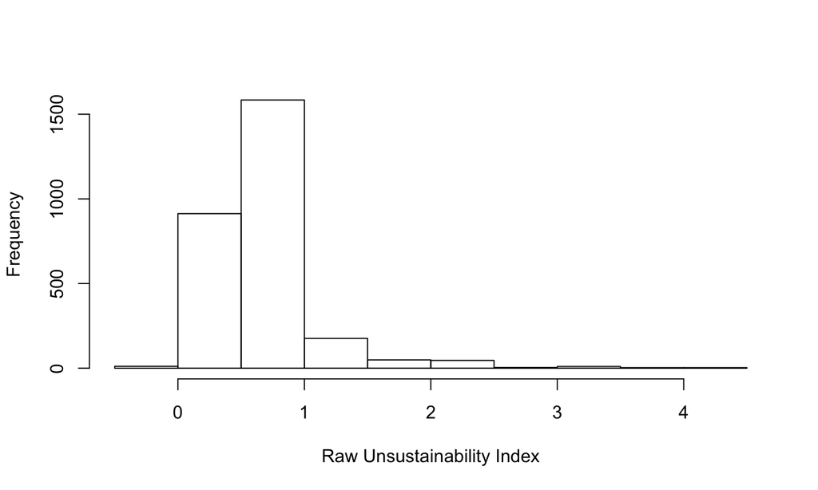

```r
hist(wdi_sub$unsustainability, main = '',
     xlab = 'Raw Unsustainability Index')
```

## Rescale the index

We could of course rescale the index so that it is between 0 and 100.

```r
wdi_sub$unsustainability <- min_max(wdi_sub$unsustainability) * 100
```

## Rescaled index

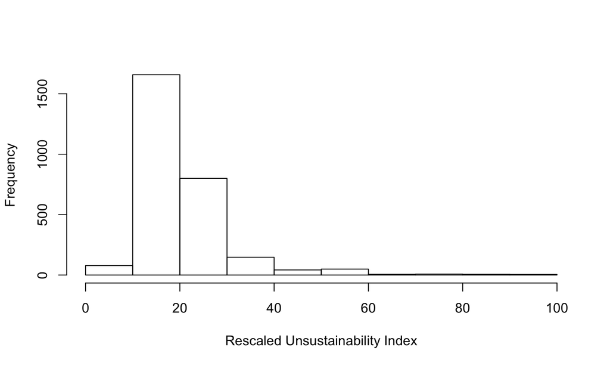

```r
hist(wdi_sub$unsustainability, main = '',
     xlab = 'Rescaled Unsustainability Index')
```

## Map the index

You could also map the results (good sanity check):

```r
# Subset data for only 2011
wdi_2011 <- subset(wdi_sub, year == 2011)

# Use the googleVis package to create the map
library(googleVis)

map <- gvisGeoChart(wdi_2011, locationvar = "country",
                    colorvar = "unsustainability")
```

## Map the index

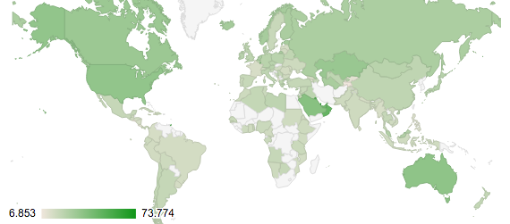

```r
plot(map)
```

## Index over time

When you create an index for units (e.g. countries) over time (e.g. years) it is useful to also plot these changes.

```r
# Select specific countries
keep <- c('China', 'Saudi Arabia', 'France', 'United States',
          'South Africa', 'United Kingdom')
wdi_countries <- subset(wdi_sub, country %in% keep)

# Plot
library(ggplot2)
index_plot <- ggplot(wdi_countries,
                     aes(x = year, y = unsustainability,
                         colour = country)) +
    geom_line() + xlab('') +
    ylab('Environmental Unsustainability Index\n') +
    theme_bw()
```

## Index over time

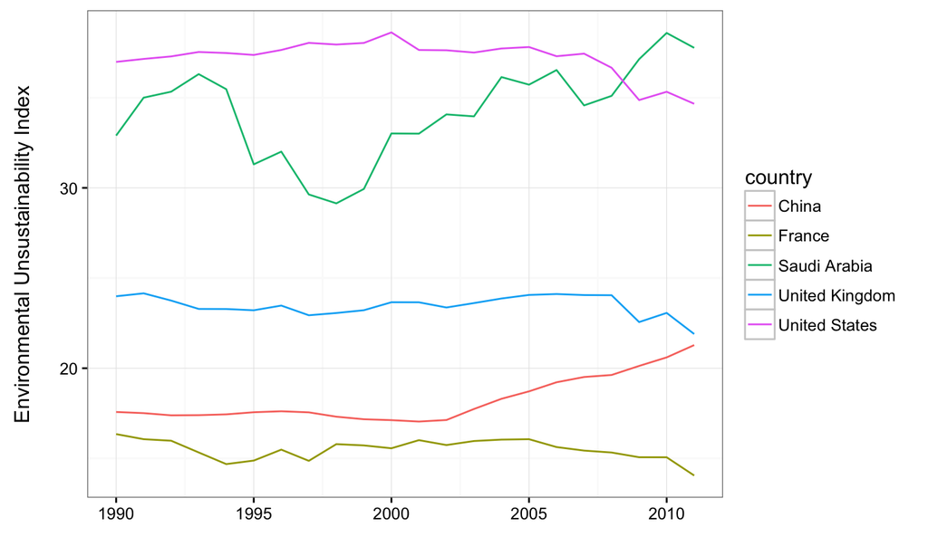

```r
index_plot
```

## Experiment

It is important to **try and compare** multiple weighting schemes to examine how sensitive the index is to each one.

## You do . . .

With a partner, using World Bank Development Indicators create an **Educational Achievement Index**:

- Select and download at least 4 indicators
- Examine and deal with missing values
- Explore the variables with a correlation matrix
- Put the variables on the same scale and reverse variable directions as need be.
- Weight and aggregate the variables into an composite index.
- Display the results (line chart and map)